# Titanic EDA

Glenn A. Bradley

2023-09-28

## Exploratory Data Analysis of the Titanic Dataset

This is a cleaned version of the titanic (training) dataset [published on Kaggle](http://www.kaggle.com/jamesleslie/titanic-cleaned_data?select=trainclean.csv). Here is a quick statistical summary.

```
##       Age           Cabin             Embarked              Fare
##  Min.   : 0.42   Length:891         Length:891         Min.   :  0.00
##  1st Qu.:22.00   Class :character   Class :character   1st Qu.:  7.91
##  Median :30.00   Mode  :character   Mode  :character   Median : 14.45
##  Mean   :29.45                                         Mean   : 32.20
##  3rd Qu.:35.50                                         3rd Qu.: 31.00
##  Max.   :80.00                                         Max.   :512.33
##      Name               Parch         PassengerId        Pclass
##  Length:891         Min.   :0.0000   Min.   :  1.0   Min.   :1.000
##  Class :character   1st Qu.:0.0000   1st Qu.:223.5   1st Qu.:2.000
##  Mode  :character   Median :0.0000   Median :446.0   Median :3.000
##                     Mean   :0.3816   Mean   :446.0   Mean   :2.309
##                     3rd Qu.:0.0000   3rd Qu.:668.5   3rd Qu.:3.000
##                     Max.   :6.0000   Max.   :891.0   Max.   :3.000
##      Sex                SibSp          Survived         Ticket
##  Length:891         Min.   :0.000   Min.   :0.0000   Length:891
##  Class :character   1st Qu.:0.000   1st Qu.:0.0000   Class :character
##  Mode  :character   Median :0.000   Median :0.0000   Mode  :character
##                     Mean   :0.523   Mean   :0.3838
##                     3rd Qu.:1.000   3rd Qu.:1.0000
##                     Max.   :8.000   Max.   :1.0000
##     Title            Family_Size
##  Length:891         Min.   : 0.0000
##  Class :character   1st Qu.: 0.0000
##  Mode  :character   Median : 0.0000
##                     Mean   : 0.9046
##                     3rd Qu.: 1.0000
##                     Max.   :10.0000
```

### Exploring the Dataset

Here is a fragment from the Titanic dataset, I’ve selected 7 columns containing various information about passengers. We will inspect them.

```
## # A tibble: 891 × 7
##    Survived Name                                 Pclass   Age Sex   Ticket Title
##       <dbl> <chr>                                 <dbl> <dbl> <chr> <chr>  <chr>
##  1        0 Braund, Mr. Owen Harris                   3    22 male  A/5 2… Mr
##  2        1 Cumings, Mrs. John Bradley (Florenc…      1    38 fema… PC 17… Mrs
##  3        1 Heikkinen, Miss. Laina                    3    26 fema… STON/… Miss
##  4        1 Futrelle, Mrs. Jacques Heath (Lily …      1    35 fema… 113803 Mrs
##  5        0 Allen, Mr. William Henry                  3    35 male  373450 Mr
##  6        0 Moran, Mr. James                          3    30 male  330877 Mr
##  7        0 McCarthy, Mr. Timothy J                   1    54 male  17463  Mr
##  8        0 Palsson, Master. Gosta Leonard            3     2 male  349909 Mast…
##  9        1 Johnson, Mrs. Oscar W (Elisabeth Vi…      3    27 fema… 347742 Mrs
## 10        1 Nasser, Mrs. Nicholas (Adele Achem)       2    14 fema… 237736 Mrs
## # ℹ 881 more rows
```

### Survival Rate by Different Variables

###### If comparing between the column named “Sex”, there were far more male passengers than female that didn’t survive.

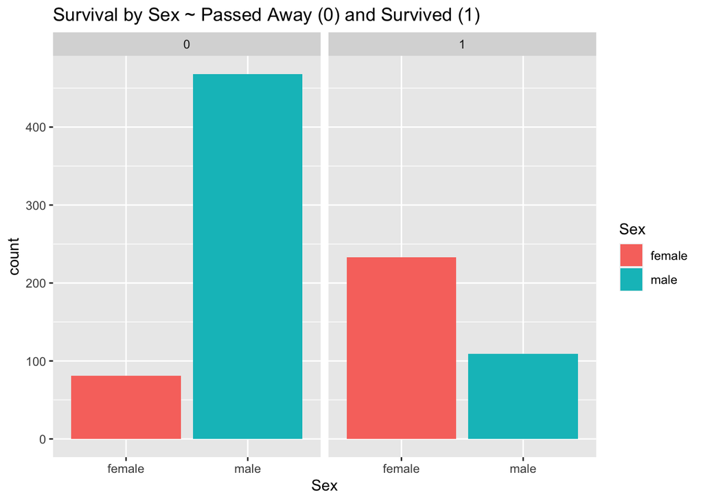

###### According to the description, the Pclass column is corresponding to the ticket classes, which is a proxy for social classes. As we can see from the chart, a lot of men died from the 2nd and 3rd clas and while the majority of women survived, the 3rd class has a lot of female victims.

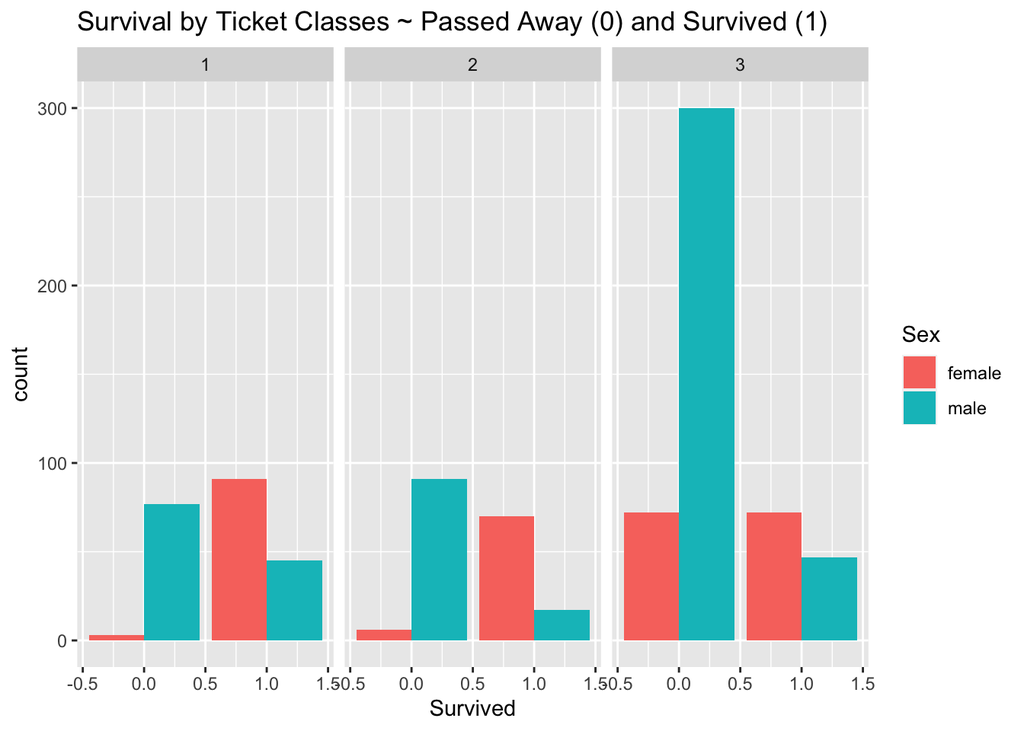

### Summary

###### After looking over our data in the Titanic dataset, we can come away with a few observations. Below, the data is grouped by Sex and ticket class, also gives up the count for each group. We can assume from the data that the odds of survival drastically improved with ticket class, women who were in 1st or 2nd class had the highest avgerage of survival. The same can’t be said for males, who no matter what class you were in had lower odds of survival.

```
##      Sex Pclass count       avg
## 1 female      1    94 0.9680851
## 2 female      2    76 0.9210526
## 3 female      3   144 0.5000000
## 4   male      1   122 0.3688525
## 5   male      2   108 0.1574074
## 6   male      3   347 0.1354467
```